# Diskusi Revisi Kurikulum dan RPS: Integrasi Generative AI untuk Akselerasi CPL

Departemen Statistika · FMIPA Universitas PadjadjaranMaju Bersama Unpad

**S1 Statistika & S2 Statistika Terapan**FMIPA Universitas Padjadjaran

Pendidikan dan Pengajaran

# Revisi Kurikulum dan RPS untuk Integrasi Generative AI

Langkah kolaboratif Program Studi S1 Statistika dan S2 Statistika Terapan untuk memperkuat pembelajaran berbasis capaian, meningkatkan kualitas RPS, dan mengakselerasi pencapaian CPL secara bertanggung jawab.

📅 Senin, 27 Juli 2026 🕘 09.00–12.00 WIB 👥 Dosen S1 Statistika & S2 Statistika Terapan

[figure not shown]

Dokumentasi Kegiatan

## Menempatkan AI sebagai bagian dari desain pembelajaran, bukan sekadar alat tambahan

Pada Senin, 27 Juli 2026, pukul 09.00–12.00 WIB, dosen Program Studi S1 Statistika dan S2 Statistika Terapan FMIPA Universitas Padjadjaran melaksanakan diskusi intensif mengenai revisi kurikulum dan Rencana Pembelajaran Semester (RPS). Agenda utama kegiatan adalah mengintegrasikan *Generative Artificial Intelligence* secara terencana untuk mendukung percepatan pencapaian Capaian Pembelajaran Lulusan (CPL).

Diskusi berlangsung serius, terbuka, dan mendetail. Pembahasan tidak berhenti pada pemilihan aplikasi AI, tetapi menelaah kembali hubungan antara CPL, CPMK, sub-CPMK, pengalaman belajar, tugas, metode asesmen, dan bukti ketercapaian pembelajaran. Dengan pendekatan ini, AI ditempatkan sebagai asisten akademik yang membantu mahasiswa belajar lebih aktif dan efisien, sementara penalaran ilmiah, verifikasi, interpretasi, dan tanggung jawab akhir tetap berada pada manusia.

Agenda**Revisi Kurikulum dan RPS**

Fokus**Integrasi Generative AI**

Kerangka**OBE dan Akselerasi CPL**

Prinsip**Produktif, transparan, terverifikasi, dan bertanggung jawab**

Arah Pembaruan

## Dari revisi dokumen menuju pengalaman belajar yang lebih bermakna

Revisi RPS diarahkan agar pemanfaatan AI benar-benar memperkuat aktivitas belajar dan asesmen, bukan hanya muncul sebagai istilah baru dalam dokumen.

CPL

### Selaras dengan capaian

Setiap aktivitas berbantuan AI harus memiliki hubungan yang jelas dengan CPL, CPMK, sub-CPMK, bahan kajian, dan bukti asesmen.

AI

### Human-in-the-loop

AI membantu eksplorasi ide, penyusunan struktur, coding, dan umpan balik awal; dosen dan mahasiswa tetap memegang kendali akademik.

✓

### Asesmen autentik

Penilaian perlu menguji kemampuan menjelaskan proses, memverifikasi keluaran, mempertahankan keputusan, dan merefleksikan penggunaan AI.

“AI boleh mempercepat proses belajar, tetapi kualitas akademik tetap ditentukan oleh rumusan masalah, bukti, metode, validasi, dan tanggung jawab manusia.”

Prinsip implementasi dalam Panduan Penggunaan AI Program Studi

Landasan Mutu

## Relevansi dengan IAPS 3.1 LAMSAMA

Dalam Kriteria Pendidikan dan Pengajaran, IAPS 3.1 LAMSAMA menempatkan integrasi AI Generatif sebagai bagian dari mutu kurikulum dan implementasi pembelajaran berbasis capaian.

**01**

### Kurikulum sistemik

Kurikulum berbasis OBE/RBE disusun melalui tahapan yang terhubung, mulai dari profil lulusan dan CPL hingga pengalaman belajar, asesmen, serta evaluasi berkelanjutan.

**02**

### Kebijakan dan panduan AI

Program studi perlu memiliki kebijakan serta panduan implementasi AI Generatif dalam pembelajaran yang mendukung dan mempercepat ketercapaian CPL.

**03**

### RPS yang siap diterapkan

RPS harus relevan dengan kedalaman dan keluasan keilmuan, menggunakan metode pembelajaran yang jelas, ditinjau berkala, dapat diakses, dan dilaksanakan secara konsisten.

**04**

### Bukti ketercapaian

Metode dan instrumen penilaian harus efektif serta menghasilkan bukti kuantitatif dan kualitatif mengenai ketercapaian CPL mahasiswa.

Ringkasan ini merujuk pada Matriks dan Panduan Penyusunan LED IAPS 3.1 LAMSAMA untuk Program Sarjana dan Program Magister. [Buka dokumen Sarjana ↗](https://lamsama.or.id/wp-content/uploads/2026/04/S1-Matriks-Penilaian-Terakreditasi-IAPS-LAMSAMA-3.1.pdf) · [Buka dokumen Magister ↗](https://lamsama.or.id/wp-content/uploads/2026/04/M-Matriks-Penilaian-Terakreditasi-Unggul-IAPS-LAMSAMA-3.1.pdf)

Panduan Penggunaan AI

## Produktif tanpa kehilangan integritas akademik

Kebijakan penggunaan AI Program Studi menekankan bahwa AI adalah asisten intelektual, bukan otoritas. Keluaran AI diperlakukan sebagai draf yang harus diuji, disaring, diperbaiki, atau ditolak berdasarkan bukti dan keahlian.

Prinsip inti

**Ask → Verify → Revise → Own**

Bertanya dengan jelas, memverifikasi sumber, merevisi secara sadar, dan mengambil tanggung jawab penuh atas keputusan akademik serta hasil akhir.

ASKVERIFYREVISEOWN

**✓**

### Gunakan secara produktif

Untuk brainstorming, outline, coding assistance, sintesis dari sumber yang telah diverifikasi, dan revisi kejelasan tulisan.

**✓**

### Verifikasi seluruh keluaran

Periksa fakta, persamaan, kode, sitasi, asumsi, interpretasi, dan konsistensi hasil pada sumber primer.

**✓**

### Jaga privasi dan hak akses

Jangan memasukkan data rahasia, sensitif, proprietary, atau belum dipublikasikan tanpa izin yang sah.

**✓**

### Transparan dan akuntabel

Ikuti ketentuan dosen, program studi, jurnal, sponsor, laboratorium, serta pemberi data; dokumentasikan bantuan material bila diperlukan.

**!**

### Hindari zona bahaya

Tidak membuat sitasi palsu, klaim tanpa evidensi, manipulasi angka atau gambar, maupun menyerahkan keputusan ilmiah sepenuhnya kepada AI.

[Buka Panduan Penggunaan AI ↗](https://statistika-unpad.github.io/pasca-statistika-web/#panduan-ai) Lihat Dokumentasi Kegiatan ↓

Fokus Implementasi

## Empat keluaran yang perlu dijaga setelah diskusi

01

### Pemetaan CPL–CPMK

Hubungan antarcapaian dan aktivitas pembelajaran terdokumentasi dengan jelas.

02

### Skenario penggunaan AI

Setiap mata kuliah menentukan penggunaan AI yang diperbolehkan, dibatasi, dan wajib diungkapkan.

03

### Rubrik asesmen

Rubrik menilai proses berpikir, verifikasi, interpretasi, refleksi, dan kualitas hasil.

04

### Evaluasi berkelanjutan

RPS ditinjau berdasarkan hasil pembelajaran, umpan balik, risiko, serta perkembangan teknologi.

Dokumentasi

## Suasana diskusi kolaboratif dan terfokus

Rangkaian foto memperlihatkan proses kerja bersama, pembahasan rinci, dan keterlibatan aktif dosen dalam penyempurnaan kurikulum serta RPS.

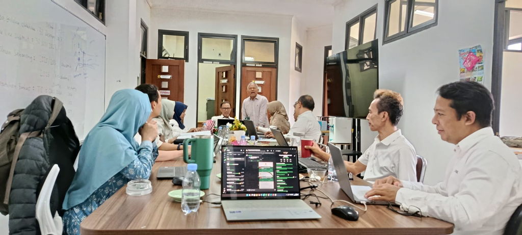

Diskusi lintas dosen untuk menyelaraskan substansi kurikulum, RPS, dan integrasi Generative AI.

[figure not shown]

Pembahasan rinci mengenai agenda, tahapan kerja, dan kebutuhan penyempurnaan dokumen.

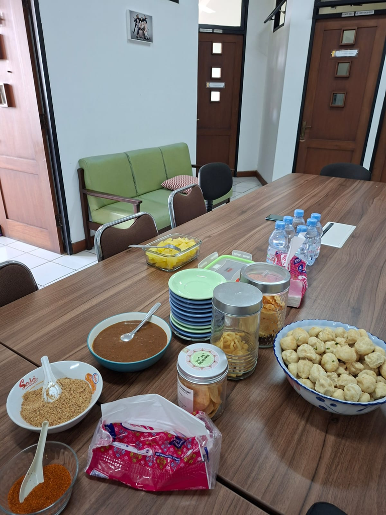

Suasana ruang kerja yang mendukung diskusi intensif selama tiga jam.

Rujukan

## Sumber kebijakan dan mutu pembelajaran

**Matriks Penilaian IAPS 3.1 LAMSAMA — Program Sarjana** · Kriteria Pendidikan dan Pengajaran

**Buka PDF ↗**

**Matriks Penilaian IAPS 3.1 LAMSAMA — Program Magister** · Kurikulum OBE/RBE, AI Generatif, RPS, dan bukti ketercapaian CPL

**Buka PDF ↗**

**Panduan Penggunaan AI — Pascasarjana Statistika FMIPA Unpad** · Penggunaan AI yang produktif, transparan, terverifikasi, dan bertanggung jawab

**Buka Panduan ↗**

[figure not shown]